# Classificando IDHM

# INTRODUÇÃO

De acordo com o Programa das Nações Unidas para o Desenvolvimento [(PNUD)](http://www.br.undp.org/content/brazil/pt/home/idh0/conceitos/o-que-e-desenvolvimento-humano.html), o conceito de desenvolvimento humano consiste em avaliar as oportunidades e capacidades individuais da população. Ao pensar em desenvolvimento humano, pode ser intuitivo associá-lo imediatamente ao ponto de vista econômico, porém a ideia é considerar também aspectos sociais, culturais e políticos.

A proposta do Índice de Desenvolvimento Humano tem por objetivo oferecer uma alternativa à análise do progresso social a partir, do ponto de vista econômico, utilizando o Produto Interno Bruto (PIB). Embora, seja uma nova possibilidade de mensurar o desenvolvimento, o índice não contempla a representação da “felicidade”, ou seja, não considera a pessoa na sua individualidade, mas seu comportamento em relação a um grupo (sociedade).

Sob a perspectiva municipal, foi adaptado o conceito de Índice de Desenvolvimento Humano para as cidades (IDHM). O indicador apresenta a mesma ideia do IDH de forma geral.

## CONTEXTUALIZAÇÃO DO PROBLEMA

Os municípios do estado do Rio de Janeiro apresentam comportamentos diferentes. Algumas diversidades podem ser observadas de acordo com a posição geográfica, a condição social, cultural, histórica, econômica, entre outras. Esses atributos podem ser responsáveis por diferentes níveis de desenvolvimento. Portanto, este trabalho consiste em classificar o IDHM a partir de informações municipais.

# DADOS

O banco de dados é formado por 92 registros, referentes aos 92 municípios do estado do Rio de Janeiro. As informações foram extraídas do [Atlas Brasil](http://www.atlasbrasil.org.br/2013/pt/consulta/) . Inicialmente, foram coletadas 226 variáveis. Em seguida, também foram obtidas informações sobre as mesorregiões correspondentes aos municípios.

O IDHM foi encontrado no formato numérico e categorizado, adaptando as categorias abaixo para apenas 3:

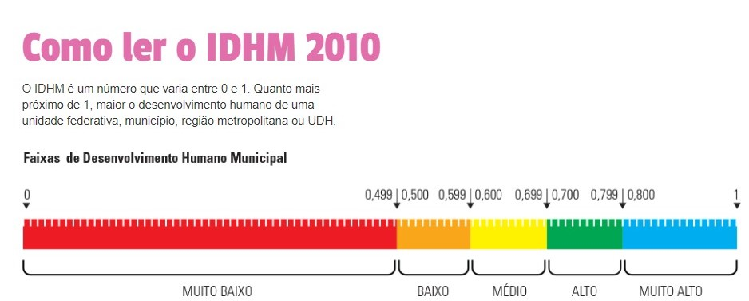

- **Alto** : Alto e Muito Alto
- **Médio**: Médio
- **Baixo**: Baixo e Muito Baixo

```r
dados2 %>%
  count(idhm)
```

```
# A tibble: 2 x 2
  idhm      n
  <chr> <int>
1 alto     57
2 médio    35
```

De acordo com o critério de classificação adotado a partir da imagem acima, podemos perceber que não existem municípios com IDHM baixo no estado do Rio de Janeiro. Portanto, existem apenas duas categorias: alto e médio.

## METODOLOGIA

Para obtermos e avaliarmos a classificação do IDHM, a base de dados foi dividida em treino e teste. A base a ser treinada conta com 80% dos municípios. As cidades restantes, que indicam 20% da base de dados, serão utilizadas para teste.

```r
set.seed(12)
index <- sample(1:nrow(dados2), 0.8*nrow(dados2))
dados_treino <- dados2[index, ]
dados_teste <- dados2[-index, ]
```

As tabelas abaixo são referentes aos dados de treino e de teste, respectivamente.

```
# A tibble: 73 x 6
   idhm  `% de empregado~ `Rendimento méd~ `% de 18 a 20 a~
   <chr>            <dbl>            <dbl>            <dbl>
 1 alto              55.6            1059.             44.4
 2 alto              55.8             996.             40.9
 3 médio             51.8             780.             34.0
 4 médio             35.0             788.             32.7
 5 alto              51.6            1248.             39.3
 6 alto              38.3            1046.             35.1
 7 alto              47.8             844.             48.7
 8 alto              53.9            1355.             40.4
 9 médio             28.6             795.             46.6
10 alto              61.1            1408.             29.7
# ... with 63 more rows, and 2 more variables: `Renda per capita
#   2010` <dbl>, Mesorregiao <chr>
```

[output not shown]

Para a classificação do IDHM foi utilizada a técnica de mineração de dados conhecida como **árvore de classificação**. A árvore analisa como cada variável influencia na distribuição do atributo a ser classificado.

Para a execução do algoritmo, utilizamos a função `rpart` do pacote `rpart` e, para a visualização da árvore, foi utilizada a função `rpart.plot` do pacote `rpart.plot`.

## MODELOS

Foram ajustados 4 modelos considerando as seguintes variáveis:

- Modelo 1: Todas as variáveis
- Modelo 2: Mesorregião
- Modelo 3: Renda per capita no ano de 2010
- Modelo 4: Percentual de empregados com carteira assinada (18 anos ou mais em 2010) , Mesorregião e Rendimento médio dos ocupados (18 anos ou mais em 2010)

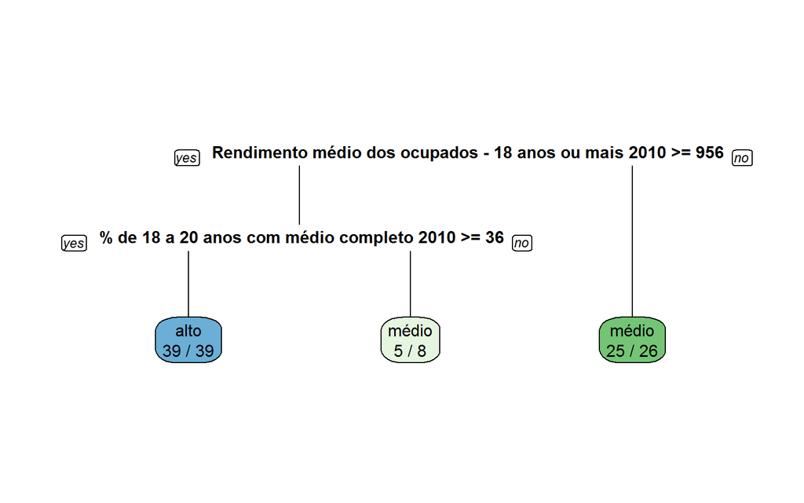

```r
modelo1 <- rpart::rpart(idhm ~ ., data = dados_treino, method = "class")
rpart.plot::rpart.plot(x = modelo1, yesno = 2,
           type = 0, extra = 2)
```

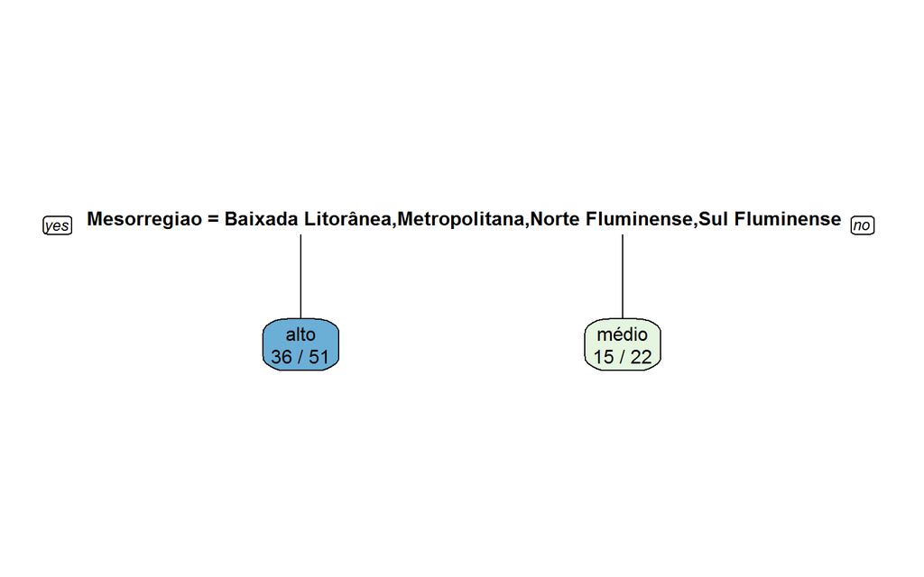

```r
modelo2 <- rpart::rpart(idhm ~ Mesorregiao, data = dados_treino,
                        method = "class")
rpart.plot::rpart.plot(x = modelo2, yesno = 2,
                       type = 0, extra = 2)
```

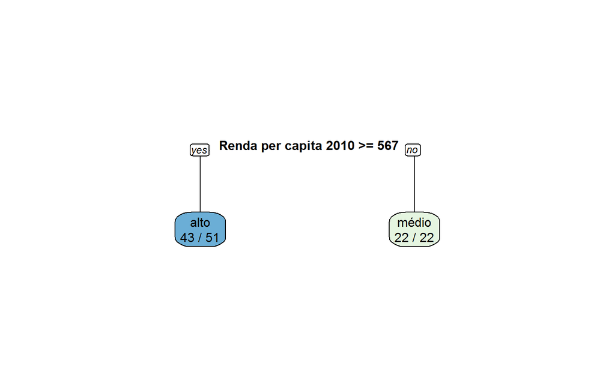

```r
modelo3 <- rpart::rpart(idhm ~ `Renda per capita 2010`,
                        data = dados_treino, method = "class")
rpart.plot::rpart.plot(x = modelo3, yesno = 2,
                       type = 0, extra = 2)
```

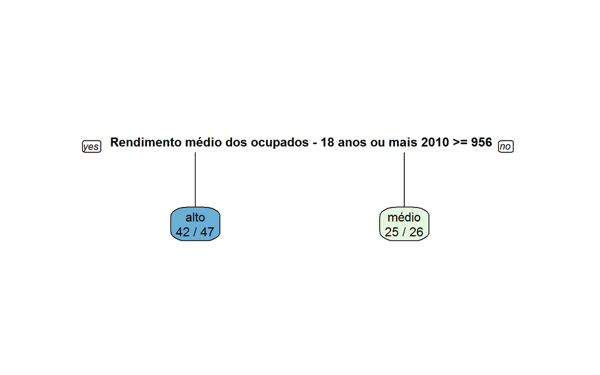

```r
modelo4 <- rpart::rpart(idhm ~ `% de empregados com carteira - 18 anos ou mais 2010` + Mesorregiao + `Rendimento médio dos ocupados - 18 anos ou mais 2010`,
                        data = dados_treino, method = "class")
rpart.plot::rpart.plot(x = modelo4, yesno = 2,
                       type = 0, extra = 2)
```

Avaliando todas as variáveis disponíveis no banco de dados, o modelo 1 utilizou como critério de classificação as variáveis Rendimento médio dos ocupados com 18 anos ou mais (2010) e Percentual de jovens de 18 a 20 anos com ensino médio completo em 2010.

Os modelos 2 e 3 foram construídos considerando apenas uma variável e o modelo 4 considerou como critério de classificação apenas a variável Rendimento médio dos ocupados com 18 anos ou mais, em 2010.

## Medidas de Avaliação

> Previsão de classificação

```r
prev1 <- predict(modelo1, dados_teste, type = "class")
prev2 <- predict(modelo2, dados_teste, type = "class")
prev3 <- predict(modelo3, dados_teste, type = "class")
prev4 <- predict(modelo4, dados_teste, type = "class")
```

> Medidas de Acurácia a partir da Matriz de Confusão

```r
# Calculando medidas de acurácia
mat_conf1 <- caret::confusionMatrix(data = prev1, reference = as.factor(dados_teste$idhm))
mat_conf2 <- caret::confusionMatrix(data = prev2, reference = as.factor(dados_teste$idhm))
mat_conf3 <- caret::confusionMatrix(data = prev3, reference = as.factor(dados_teste$idhm))
mat_conf4 <- caret::confusionMatrix(data = prev4, reference = as.factor(dados_teste$idhm))
```

A seguir veremos a matriz de confusão correspondente a cada modelo:

```
          Reference
Prediction alto médio
     alto     9     1
     médio    5     4
```

```
          Reference
Prediction alto médio
     alto     9     3
     médio    5     2
```

```
          Reference
Prediction alto médio
     alto    13     2
     médio    1     3
```

```
          Reference
Prediction alto médio
     alto    11     1
     médio    3     4
```

```r
rbind(mat_conf1$overall, mat_conf2$overall,
      mat_conf3$overall, mat_conf4$overall) %>%
  cbind(rbind(mat_conf1$byClass, mat_conf2$byClass,
        mat_conf3$byClass, mat_conf4$byClass)) %>%
  as_data_frame() %>%
  mutate(Modelo = paste("Modelo", 1:4)) %>%
  select(Modelo, -Kappa, -starts_with("Accuracy"), Accuracy, Sensitivity,
         Specificity) %>%
  arrange_at(vars(-Modelo), desc)
```

```
# A tibble: 4 x 4
  Modelo   Accuracy Sensitivity Specificity
  <chr>       <dbl>       <dbl>       <dbl>
1 Modelo 3    0.842       0.929         0.6
2 Modelo 4    0.789       0.786         0.8
3 Modelo 1    0.684       0.643         0.8
4 Modelo 2    0.579       0.643         0.4
```

Quanto maior a sensitividade, mais elementos positivos são classificados, de fato, como positivos, ou seja, municípios de IDHM alto sendo considerados como altos.

Por outro lado, a especificidade tem maior precisão para classificar negativos como, de fato, negativos, ou seja, classifica melhor o IDHM médio.

Entende-se por acurácia a proporção de acertos na base de teste.

# CONCLUSÃO

De acordo com a acurácia, o modelo 3 tem maior proporção de acertos. O modelo 3 também apresenta maior sensitividade. Portanto ao classificar um município que possui realmente um IDHM alto, esse modelo tem o melhor desempenho.

De acordo com a especificidade, o modelo 1 e o modelo 4 são os que mais acertam IDHM médio, mas como o modelo 4 possui maior acurácia e sensitividade, podemos afirmar que seu desempenho é melhor do que o do modelo 1.

Camila Simões, Jessyka Goltara, Leonardo Filgueira

09/10/2018